# STOR 455 Assignment 2

Ted Henson

September 9, 2018

```r
setwd("~/STOR 455")
UsedCarLot <- read_csv("UsedCarLot.csv")
honda <- UsedCarLot[which(UsedCarLot$make == 'Honda'),]
accord <- honda[which(honda$model == 'Accord'),]
```

## Exercises 1 & 2

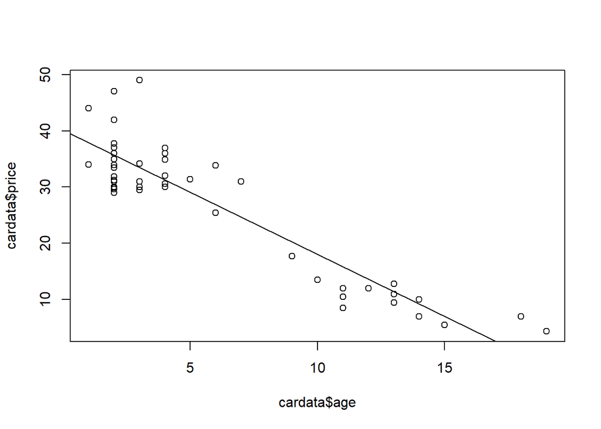

```r
cardata <- accord
cardata$age <- 2018 - cardata$year
linear <- lm(price~age, data = cardata)
plot(x = cardata$age, y = cardata$price)
abline(linear)
```

```r
summary(linear)
```

```
##
## Call:
## lm(formula = price ~ age, data = cardata)
##
## Residuals:
##    Min     1Q Median     3Q    Max
## -7.339 -3.865 -1.368  2.223 15.481
##
## Coefficients:
##             Estimate Std. Error t value Pr(>|t|)
## (Intercept)  40.1322     1.1396   35.22   <2e-16 ***
## age          -2.2085     0.1473  -14.99   <2e-16 ***
## ---
## Signif. codes:  0 '***' 0.001 '**' 0.01 '*' 0.05 '.' 0.1 ' ' 1
##
## Residual standard error: 5.161 on 48 degrees of freedom
## Multiple R-squared:  0.824,  Adjusted R-squared:  0.8203
## F-statistic: 224.7 on 1 and 48 DF,  p-value: < 2.2e-16
```

The slope estimate of -2.2085 means that for every year the honda accord ages, it’s value decreases by $2,2085. The negative slope makes sense because a car’s price will decrease with age.

## Exercise 3

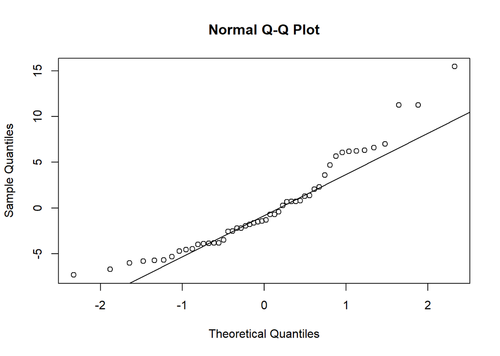

```r
qqnorm(linear$residuals)
qqline(linear$residuals)
```

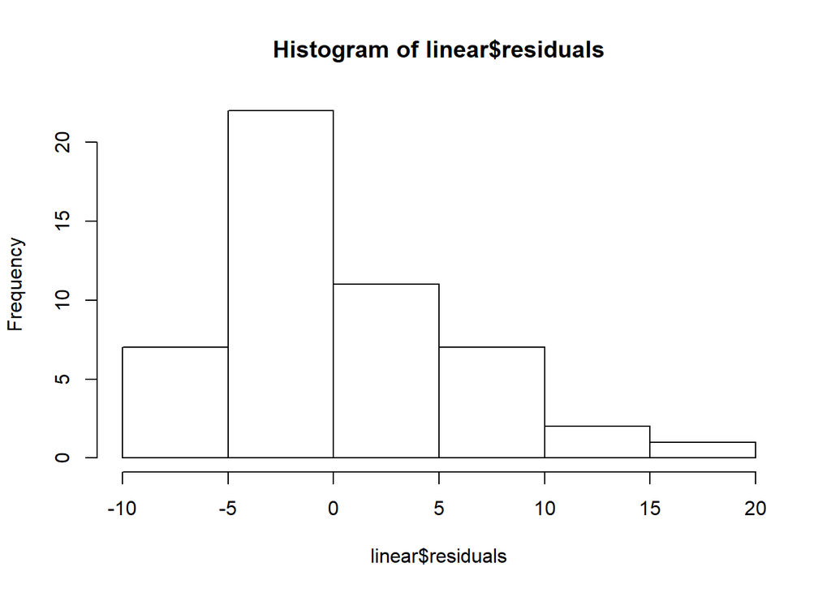

```r
hist(linear$residuals)
```

## Exercise 4

```r
outlier <- which(linear$residuals == max(abs(linear$residuals)))
print(outlier)
```

```
## 37
## 37
```

```r
students <- rstudent(linear)
standard <- rstandard(linear)
students[outlier]
```

```
##       37
## 3.349296
```

```r
standard[outlier]
```

```
##       37
## 3.041209
```

Both student and starndized residuals are more than 3 standard deviations away from the mean so the data point should probably be classified as an outlier.

## Exercise 5

```r
interval <- confint(linear, level = .90)
interval
```

```
##                  5 %      95 %
## (Intercept) 38.22081 42.043526
## age         -2.45566 -1.961407
```

We can say with 90% confidence that the slope of the best fine line of these variables is between the interval (-2.45566, -1.961407).

## Exercise 6

```r
cor.test(cardata$price, cardata$age)
```

```
##
##  Pearson's product-moment correlation
##
## data:  cardata$price and cardata$age
## t = -14.989, df = 48, p-value < 2.2e-16
## alternative hypothesis: true correlation is not equal to 0
## 95 percent confidence interval:
##  -0.9468411 -0.8421606
## sample estimates:
##        cor
## -0.9077253
```

```r
summary(linear)
```

```
##
## Call:
## lm(formula = price ~ age, data = cardata)
##
## Residuals:
##    Min     1Q Median     3Q    Max
## -7.339 -3.865 -1.368  2.223 15.481
##
## Coefficients:
##             Estimate Std. Error t value Pr(>|t|)
## (Intercept)  40.1322     1.1396   35.22   <2e-16 ***
## age          -2.2085     0.1473  -14.99   <2e-16 ***
## ---
## Signif. codes:  0 '***' 0.001 '**' 0.01 '*' 0.05 '.' 0.1 ' ' 1
##
## Residual standard error: 5.161 on 48 degrees of freedom
## Multiple R-squared:  0.824,  Adjusted R-squared:  0.8203
## F-statistic: 224.7 on 1 and 48 DF,  p-value: < 2.2e-16
```

```r
anova(linear)
```

```
## Analysis of Variance Table
##
## Response: price
##           Df Sum Sq Mean Sq F value    Pr(>F)
## age        1 5984.0  5984.0  224.67 < 2.2e-16 ***
## Residuals 48 1278.4    26.6
## ---
## Signif. codes:  0 '***' 0.001 '**' 0.01 '*' 0.05 '.' 0.1 ' ' 1
```

## Exercise 7

```r
#subset for just 5 year old cars?
theanswer <- linear$coefficients[2]*5 + linear$coefficients[1]
theanswer
```

```
##     age
## 29.0895
```

Our model predicts that a five year old Honda Accord will cost $29,0895.

```r
whoknows <- data.frame(age=5)
predict.lm(linear, whoknows, interval = 'confidence')
```

```
##       fit      lwr      upr
## 1 29.0895 27.59585 30.58315
```

```r
predict.lm(linear, whoknows, interval = 'prediction')
```

```
##       fit      lwr      upr
## 1 29.0895 18.60603 39.57297
```

## Exercise 8

```r
y  = linear$coefficients[1] / -linear$coefficients[2]
y
```

```
## (Intercept)
##    18.17141
```

According to the model a car over 18.17141 years of age should be free. This phenomenon shows that our model does not do a good job of estimating prices for cars that are very old, because although an 18.17 year old car would be very cheap, it would not be free.

## Exercise 9

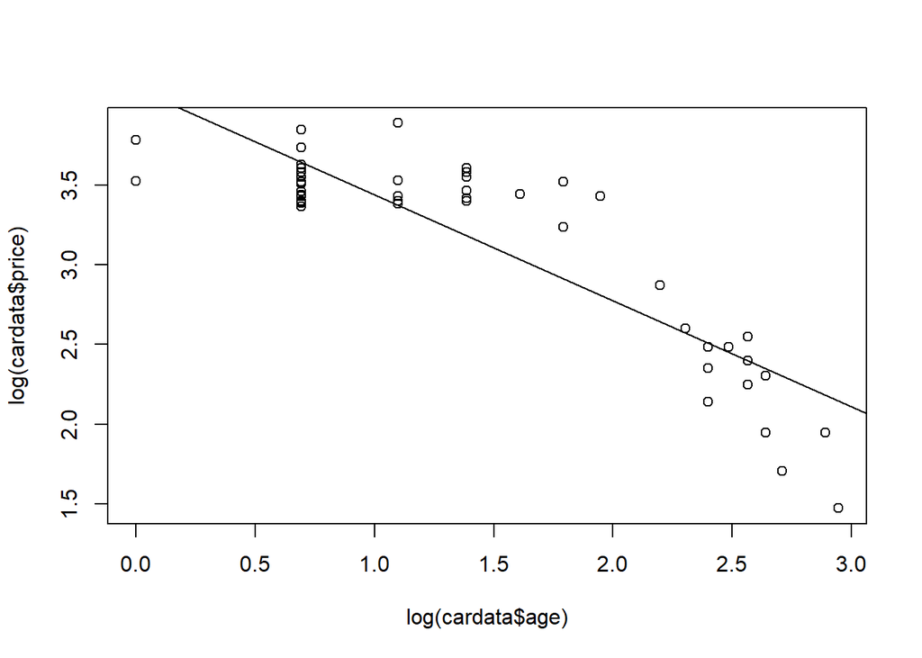

```r
linear <- lm(log(price)~log(age), data = cardata)
plot(x = log(cardata$age), y = log(cardata$price))
abline(linear)
```

```r
summary(linear)
```

```
##
## Call:
## lm(formula = log(price) ~ log(age), data = cardata)
##
## Residuals:
##     Min      1Q  Median      3Q     Max
## -0.6738 -0.2085 -0.0188  0.2151  0.6236
##
## Coefficients:
##             Estimate Std. Error t value Pr(>|t|)
## (Intercept)  4.10573    0.08674   47.34   <2e-16 ***
## log(age)    -0.66573    0.05225  -12.74   <2e-16 ***
## ---
## Signif. codes:  0 '***' 0.001 '**' 0.01 '*' 0.05 '.' 0.1 ' ' 1
##
## Residual standard error: 0.3024 on 48 degrees of freedom
## Multiple R-squared:  0.7718, Adjusted R-squared:  0.767
## F-statistic: 162.3 on 1 and 48 DF,  p-value: < 2.2e-16
```

This model has a lower R squared than the standard regression. This model may be better for very new and very old cars, but on average this model performs worse.